# CTED Achievement Profile

Samuel Irvin

2023-08-30

# WEST-MEC - WESTERN MARICOPA EDUCATION CENTER

[Back to CTED List](https://azcteaccountability.github.io/CTEDAchievementProfiles)

### FY 2024 - 2025 CTED Achievement Profile

| Statutorily Required Criteria | Additional Criteria |
| --- | --- |
| Graduation rate of all students enrolled in a CTE program. | Graduation rate disaggregated by population, for both CTE participants and concentrators, and disaggregated by campus type, additional comparison metrics. |
| The completion rate for each program offered by the CTED. | The program completion rate disaggregated by program and campus type, additional comparison metrics. |
| Performance on technical skills assessments. | TSA attempt and pass rates, disaggregated by program and campus type, additional comparison metrics. |
| Postgraduation employment rates, postsecondary enrollment rates, and military service rates for program completers. | Postgraduation advanced training rates, participation in a national service program rate, and placement rates disaggregated by campus type, additional comparison metrics. |
|  | Performance on industry-recognized credential assessments, including attempt and pass rates, disaggregated by program and campus type, additional comparison metrics. |

# DEFINITIONS

**CTE Participant**

A CTE participant is any student that completes and passes at least one CTE course worth at least one credit in a CTE program.

**CTE Concentrator**

A CTE concentrator is a student that completes and passes at least different two courses worth at least one credit each in a single CTE program. Internships and cooperative education are not included in determining concentrator status.

**Program Completer**

A program completer is a student that passes all the required courses in a single CTE program having earned a minimum of one credit in each required course. Internships and cooperative education courses are not included in determining program completion status.

**Technical Skills Assessment**

The Technical Skills Assessment (TSA) is a comprehensive end-of-program assessment designed to certify a student’s understanding and mastery of industry-validated knowledge and skill. TSA assessments are not credential assessments.

**Industry-recognized Credentials**

Credentials are third-party issued and industry-recognized and widely accepted certificates, licenses, and other credentials that signify a student’s mastery of industry-validated knowledge and skill. These credentials are not issued by ADE.

# CTED CAMPUSES

### CTED Central Campuses

| West-MEC - Central Campus |
| --- |
| West-MEC - Estrella Mt Community College |
| West-MEC - Gateway Community College |
| West-MEC - Glendale Community College |
| West-MEC - Northeast Campus |
| West-MEC - Northwest Campus |
| West-MEC - Paradise Valley Community College |
| West-MEC - Southwest Campus |

### Member Districts & Satellite Campuses

| **Agua Fria Union High School District** |
| --- |
| Agua Fria High School |
| Canyon View High School |
| Coldwater Academy |
| Desert Edge High School |
| Millennium High School |
| Verrado High School |
| **Buckeye Union High School District** |
| Buckeye UHSD Institute of Online Learning |
| Buckeye Union High School |
| Estrella Foothills High School |
| Youngker High School |
| **Deer Valley Unified District** |
| Aspire, Deer Valley’s Online Academy |
| Barry Goldwater High School |
| Boulder Creek High School |
| Deer Valley High School |
| Mountain Ridge High School |
| Sandra Day O’Connor High School |
| Vista Peak |
| **Dysart Unified District** |
| Dysart High School |
| Dysart iSchool |
| Shadow Ridge High School |
| Valley Vista High School |
| Willow Canyon High School |
| **Gila Bend Unified District** |
| Gila Bend High School |
| **Glendale Union High School District** |
| Apollo High School |
| Cortez High School |
| Glendale High School |
| Glendale Union High School District Online Learning Academy |
| Glendale Union Online |
| Greenway High School |
| Independence High School |
| Moon Valley High School |
| Sunnyslope High School |
| Thunderbird High School |
| Washington High School |
| **Nadaburg Unified School District** |
| Mountainside High School |
| **Paradise Valley Unified District** |
| Horizon High School |
| North Canyon High School |
| Paradise Valley High School |
| Pinnacle High School |
| Shadow Mountain High School |
| Star Tech Professional Center |
| Sweetwater Community School |
| **Paragon Management, Inc.** |
| Paradise Honors High School |
| **Peoria Unified School District** |
| Cactus High School |
| Centennial High School |
| Ironwood High School |
| Liberty High School |
| Peoria eCampus |
| Peoria Flex Academy |
| Peoria High School |
| Raymond S. Kellis |
| Sunrise Mountain High School |
| **Ridgeline Academy, Inc.** |
| Ridgeline Academy, Inc. |
| **Saddle Mountain Unified School District** |
| Tonopah Valley High School |
| **Tolleson Union High School District** |
| Copper Canyon High School |
| La Joya Community High School |
| Sierra Linda High School |
| Tolleson Union High School |
| Tolleson Virtual High School |
| University High School |
| West Point High School |
| Westview High School |
| **Wickenburg Unified District** |
| Wickenburg High School |

All data in this profile is disaggregated by campus type and is displayed as “CTED Central Campus” or “Central + Satellite”. CTED Central campus data includes only the data reported by the campuses in the central campuses list above. Central + Satellite data includes data reported by the campuses in both the central campuses and member districts lists above. Data is deduplicated, meaning that if a student is reported by multiple entities, they are counted only once wherever possible.

# GRADUATION RATE

The graduation rate is calculated using the student’s 4-year cohort as a base. The graduation rate is calculated as the number of participants or concentrators that graduated with their cohort divided by the total number of participants or concentrators in the cohort, respectively. Graduation rate is calculated using the 2024 cohort in this Profile.

#### West-MEC - Western Maricopa Education Center’s Central + Satellite Campuses

##### **CTE Participants**

93%

##### **CTE Concentrators**

97.4%

#### West-MEC - Western Maricopa Education Center’s Central Campuses

##### **CTE Participants**

98.3%

##### **CTE Concentrators**

98.6%

#### Arizona

##### **All CTE and non-CTE Students in Cohort**

78.4%

### Data

| Student | Graduating | All |
| --- | --- | --- |
| **CTED Central Campus** |  |  |
| CTE Participants | 1370 | 1393 |
| CTE Concentrators | 1335 | 1354 |
| **Central + Satellite Campuses** |  |  |
| CTE Participants | 15943 | 17140 |
| CTE Concentrators | 9066 | 9312 |

### Chart

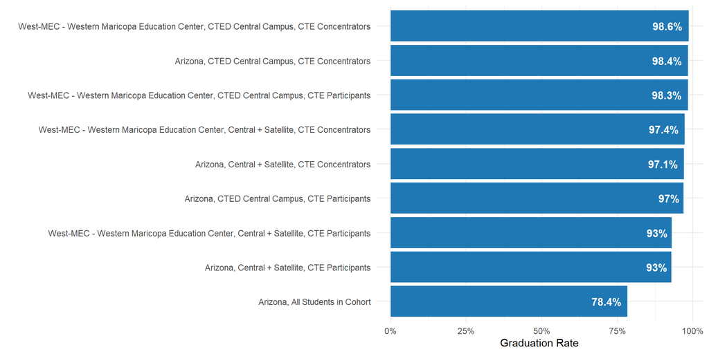

# PROGRAM COMPLETION

The program completion rate is calculated as the number of students in the cohort that completed a CTE program divided by the number of students in the same cohort that enrolled in a CTE program. The term “completed a CTE program” means the student has passed the minimum required number of courses in the program having earned at least one credit in each required course. Program completion is calculated using 2025 cohort in this Profile.

Empty cells in the table below indicate that the program did not have program completers at the campus type(s) specified in that column, but that campus type may have had students enrolled in the program.

#### West-MEC - Western Maricopa Education Center’s Central + Satellite Campuses

##### **Program Completion Rate**

49.1%

#### West-MEC - Western Maricopa Education Center’s Central Campuses

##### **Program Completion Rate**

89.8%

#### Arizona’s CTED Central and Satellite Campuses

##### **Program Completion Rate**

47.6%

#### Arizona’s CTED Central Campuses

##### **Program Completion Rate**

70.1%

### Data

| Program | Central + Satellite Program Completers | Central + Satellite Program Enrollees | Central + Satellite Program Completion Rate | CTED Central Campus Program Completers | CTED Central Campus Program Enrollees | CTED Central Campus Program Completion Rate |
| --- | --- | --- | --- | --- | --- | --- |
| Accounting | 33 | 404 | 8.2% | NA | NA | NA |
| Aesthetics | 92 | 93 | 98.9% | 92 | 93 | 98.9% |
| Agriscience | 163 | 515 | 31.7% | NA | NA | NA |
| Aircraft Mechanics | 30 | 45 | 66.7% | 30 | 44 | 68.2% |
| Automation and Robotics | 23 | 120 | 19.2% | 18 | 18 | 100% |
| Automotive Collision Repair | 17 | 22 | 77.3% | 17 | 19 | 89.5% |
| Automotive Technologies | 196 | 905 | 21.7% | 72 | 88 | 81.8% |
| Baking and Pastry Arts | 102 | 150 | 68% | NA | NA | NA |
| Bioscience | 104 | 223 | 46.6% | 15 | 16 | 93.8% |
| Business Management | 171 | 575 | 29.7% | NA | NA | NA |
| Business Operations | 109 | 570 | 19.1% | NA | NA | NA |
| Carpentry | 104 | 242 | 43% | NA | NA | NA |
| Construction Technologies | 349 | 1116 | 31.3% | 38 | 38 | 100% |
| Cosmetology and Related Services | 68 | 74 | 91.9% | 67 | 70 | 95.7% |
| Culinary Arts | 1902 | 4618 | 41.2% | 15 | 15 | 100% |
| Dental Assisting | 86 | 89 | 96.6% | 86 | 88 | 97.7% |
| Diesel Engine Repair | 14 | 16 | 87.5% | 14 | 16 | 87.5% |
| Digital Animation | 50 | 168 | 29.8% | NA | NA | NA |
| Digital Communication | 59 | 384 | 15.4% | 7 | 7 | 100% |
| Digital Photography | 232 | 1577 | 14.7% | NA | NA | NA |
| Early Childhood Education | 441 | 1984 | 22.2% | NA | NA | NA |
| Education Professions | 137 | 475 | 28.8% | NA | NA | NA |
| Electrical and Power Transmission Installation | 95 | 99 | 96% | 95 | 98 | 96.9% |
| Electronic Technologies | 0 | 1 | 0% | NA | NA | NA |
| Emergency Medical Services | 71 | 86 | 82.6% | 26 | 66 | 39.4% |
| Energy Systems | 0 | 1 | 0% | NA | NA | NA |
| Energy and Industrial Technology | 36 | 36 | 100% | 36 | 36 | 100% |
| Engineering | 291 | 1667 | 17.5% | NA | NA | NA |
| Fashion Design and Operations | 45 | 200 | 22.5% | NA | NA | NA |
| Film and TV Production | 584 | 2450 | 23.8% | NA | NA | NA |
| Finance | 124 | 554 | 22.4% | NA | NA | NA |
| Fire Service | 132 | 345 | 38.3% | 30 | 32 | 93.8% |
| Graphic Design | 480 | 2153 | 22.3% | NA | NA | NA |
| Heating, Ventilation and Air Conditioning | 22 | 23 | 95.7% | 21 | 23 | 91.3% |
| Home Health Aide | 66 | 255 | 25.9% | NA | NA | NA |
| Hospitality Management | 79 | 449 | 17.6% | NA | NA | NA |
| Interior Design | 12 | 90 | 13.3% | NA | NA | NA |
| JROTC Air Force/Spaceforce | 172 | 347 | 49.6% | NA | NA | NA |
| JROTC Army | 15 | 36 | 41.7% | NA | NA | NA |
| JROTC Navy/Marine Corp | 171 | 453 | 37.7% | NA | NA | NA |
| Laboratory Assisting | 46 | 80 | 57.5% | 46 | 46 | 100% |
| Law and Public Safety | 437 | 1882 | 23.2% | 36 | 36 | 100% |
| Marine Power and Extreme Sports Technologies | 20 | 20 | 100% | 20 | 20 | 100% |
| Marketing | 838 | 3709 | 22.6% | NA | NA | NA |
| Mechanical Drafting | 4 | 13 | 30.8% | NA | NA | NA |
| Medical Assisting Services | 760 | 1540 | 49.4% | 233 | 235 | 99.1% |
| Music and Audio Production | 2 | 17 | 11.8% | NA | NA | NA |
| Network Security | 102 | 156 | 65.4% | 60 | 61 | 98.4% |
| Nursing Services | 170 | 289 | 58.8% | 36 | 36 | 100% |
| Pharmacy Support Services | 86 | 90 | 95.6% | 86 | 90 | 95.6% |
| Physical Therapy Assistant | 94 | 102 | 92.2% | 81 | 99 | 81.8% |
| Precision Machining | 6 | 14 | 42.9% | 5 | 13 | 38.5% |
| Software and App Design | 703 | 2683 | 26.2% | 52 | 60 | 86.7% |
| Sports Medicine and Rehabilitation | 1047 | 3324 | 31.5% | NA | NA | NA |
| Stagecraft | 97 | 361 | 26.9% | NA | NA | NA |
| Technology Devices Maintenance | 24 | 95 | 25.3% | NA | NA | NA |
| Veterinary Assisting | 119 | 158 | 75.3% | 113 | 156 | 72.4% |
| Water Quality and Wastewater Treatment Management and Recycling Technology | 13 | 15 | 86.7% | 9 | 15 | 60% |
| Welding Technologies | 252 | 534 | 47.2% | 45 | 45 | 100% |
| sUAS Drones | 17 | 18 | 94.4% | 17 | 18 | 94.4% |

### Chart

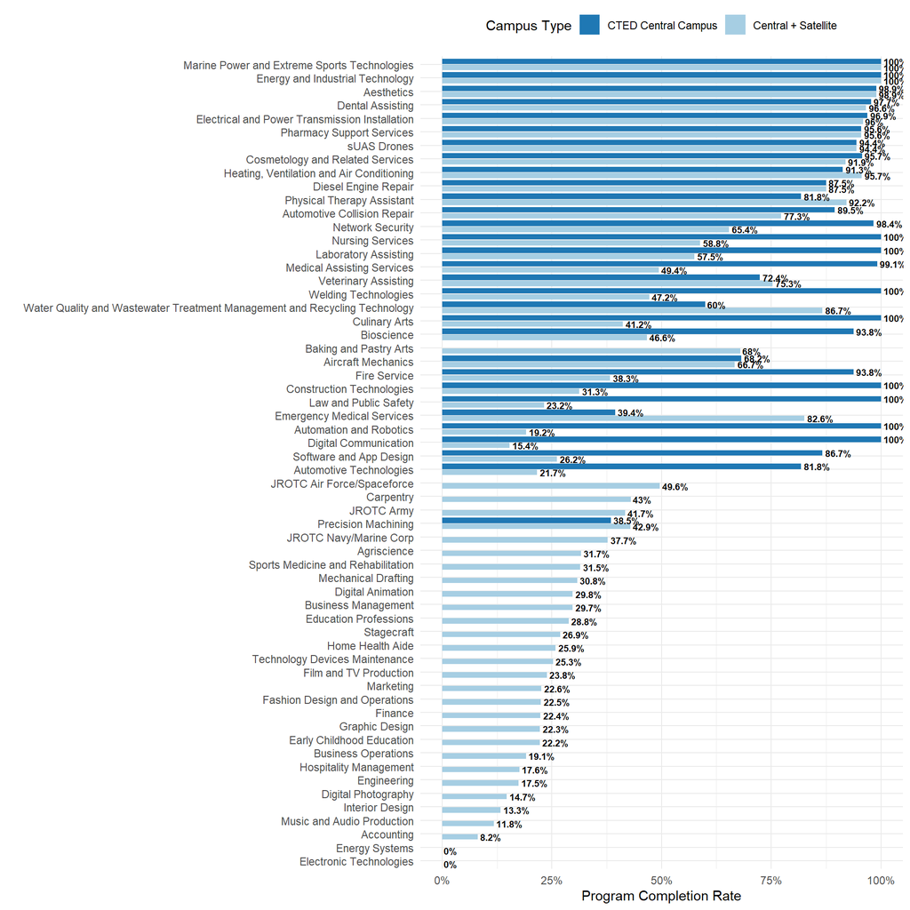

### Alternative Method

An alternative method to calculating program completion rate is to divide the number of program completers by the number of students that completed/passed at least the first course in the program. This method discounts any student that did not pass at least the first course of a program, but more accurately portrays program completion and retention among students that are attempting to complete the program.

| Program | Campus Type | Program Completers | Program Enrollees | Program Completion Rate |
| --- | --- | --- | --- | --- |
| All Programs | Central + Satellite | 9547 | 18096 | 52.8% |
| All Programs | CTED Central Campus | 1491 | 1661 | 89.8% |
| Accounting | Central + Satellite | 33 | 391 | 8.4% |
| Aesthetics | Central + Satellite | 92 | 93 | 98.9% |
| Aesthetics | CTED Central Campus | 92 | 93 | 98.9% |
| Agriscience | Central + Satellite | 163 | 497 | 32.8% |
| Aircraft Mechanics | Central + Satellite | 30 | 45 | 66.7% |
| Aircraft Mechanics | CTED Central Campus | 30 | 44 | 68.2% |
| Automation and Robotics | Central + Satellite | 23 | 120 | 19.2% |
| Automation and Robotics | CTED Central Campus | 18 | 18 | 100% |
| Automotive Collision Repair | Central + Satellite | 17 | 22 | 77.3% |
| Automotive Collision Repair | CTED Central Campus | 17 | 19 | 89.5% |
| Automotive Technologies | Central + Satellite | 196 | 867 | 22.6% |
| Automotive Technologies | CTED Central Campus | 72 | 88 | 81.8% |
| Baking and Pastry Arts | Central + Satellite | 102 | 149 | 68.5% |
| Bioscience | Central + Satellite | 104 | 223 | 46.6% |
| Bioscience | CTED Central Campus | 15 | 16 | 93.8% |
| Business Management | Central + Satellite | 171 | 547 | 31.3% |
| Business Operations | Central + Satellite | 109 | 451 | 24.2% |
| Carpentry | Central + Satellite | 104 | 241 | 43.2% |
| Construction Technologies | Central + Satellite | 349 | 1027 | 34% |
| Construction Technologies | CTED Central Campus | 38 | 38 | 100% |
| Cosmetology and Related Services | Central + Satellite | 68 | 74 | 91.9% |
| Cosmetology and Related Services | CTED Central Campus | 67 | 70 | 95.7% |
| Culinary Arts | Central + Satellite | 1902 | 4342 | 43.8% |
| Culinary Arts | CTED Central Campus | 15 | 15 | 100% |
| Dental Assisting | Central + Satellite | 86 | 89 | 96.6% |
| Dental Assisting | CTED Central Campus | 86 | 88 | 97.7% |
| Diesel Engine Repair | Central + Satellite | 14 | 16 | 87.5% |
| Diesel Engine Repair | CTED Central Campus | 14 | 16 | 87.5% |

[output cut: 63 more lines]

# TECHNICAL SKILLS ASSESSMENT

The CTE technical skills assessment, or TSA, is a comprehensive end-of-program assessment designed to certify a student’s understanding and mastery of industry-validated knowledge and skill. TSA assessments are not credential assessments, but rather students are issued a certificate of passing by the Arizona Department of Education and endorsed by the Arizona CTE Quality Commission.

#### Technical Skills Assessment Pass Rates

TSA pass rates are calculated as the number of students in the reporting year cohort that attempted the TSA for their CTE program and passed it divided by the number of students in the same cohort that attempted the TSA for their program. TSA pass rates include all students who attempt the TSA regardless of CTE concentrators status.

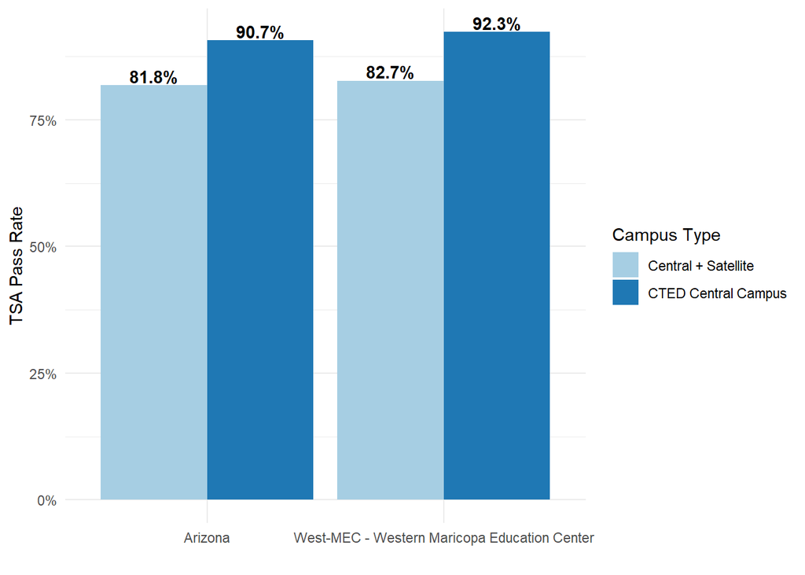

#### Technical Skills Assessment Attempt Rates

The attempt rate for technical skills assessment is calculated as the number of CTE concentrators in the reporting year cohort who attempt the TSA for their program divided by the total number of CTE concentrators in the cohort. Attempt rate is calculated using CTE concentrators rather than all students as students are typically expected to attempt the TSA after becoming a CTE concentrator.

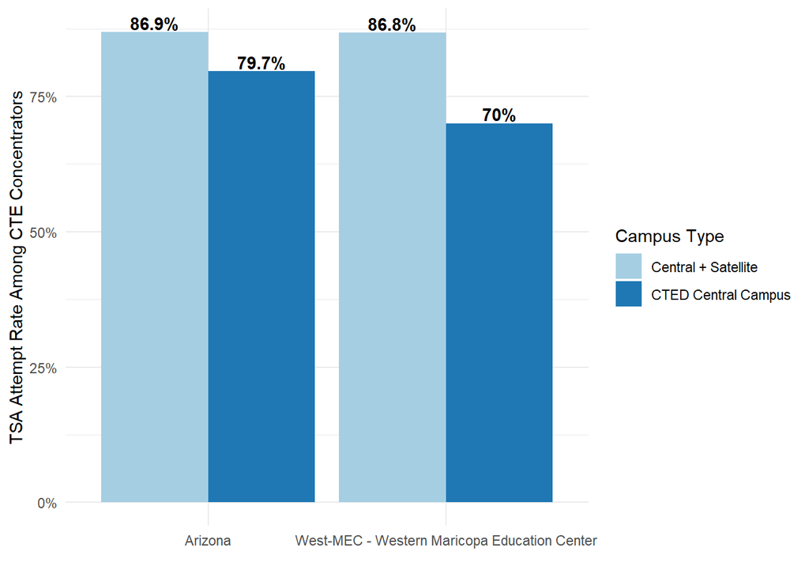

#### TSA Pass and Attempt Rates by Program

### Pass Rates

TSA pass rates are calculated as the number of students in the reporting year cohort that attempted the TSA for their CTE program and passed it divided by the number of students in the same cohort that attempted the TSA for their program.

| Campus Type | Program Name | Number of Cohort Students that Passed the TSA | Number of Cohort Students that Took the TSA | TSA Pass Rate |
| --- | --- | --- | --- | --- |
| Central + Satellite | Accounting | 28 | 38 | 73.7% |
| Central + Satellite | Agriscience | 115 | 161 | 71.4% |
| Central + Satellite | Aircraft Mechanics | 36 | 43 | 83.7% |
| CTED Central Campus | Aircraft Mechanics | 36 | 43 | 83.7% |
| Central + Satellite | Automation and Robotics | 27 | 35 | 77.1% |
| CTED Central Campus | Automation and Robotics | 17 | 18 | 94.4% |
| Central + Satellite | Automotive Collision Repair | 14 | 14 | 100% |
| CTED Central Campus | Automotive Collision Repair | 14 | 14 | 100% |
| Central + Satellite | Automotive Technologies | 125 | 201 | 62.2% |
| CTED Central Campus | Automotive Technologies | 62 | 71 | 87.3% |
| Central + Satellite | Bioscience | 83 | 90 | 92.2% |
| CTED Central Campus | Bioscience | 9 | 11 | 81.8% |
| Central + Satellite | Business Management | 125 | 168 | 74.4% |
| Central + Satellite | Business Operations | 87 | 113 | 77% |
| Central + Satellite | Carpentry | 45 | 92 | 48.9% |
| Central + Satellite | Construction Technologies | 93 | 316 | 29.4% |
| CTED Central Campus | Construction Technologies | 19 | 28 | 67.9% |
| Central + Satellite | Cosmetology and Related Services | 63 | 63 | 100% |
| CTED Central Campus | Cosmetology and Related Services | 63 | 63 | 100% |
| Central + Satellite | Culinary Arts | 1516 | 1813 | 83.6% |
| CTED Central Campus | Culinary Arts | 15 | 15 | 100% |
| Central + Satellite | Dental Assisting | 75 | 77 | 97.4% |
| CTED Central Campus | Dental Assisting | 75 | 77 | 97.4% |
| Central + Satellite | Diesel Engine Repair | 11 | 14 | 78.6% |
| CTED Central Campus | Diesel Engine Repair | 11 | 14 | 78.6% |
| Central + Satellite | Digital Animation | 44 | 51 | 86.3% |
| Central + Satellite | Digital Communication | 52 | 71 | 73.2% |
| CTED Central Campus | Digital Communication | 7 | 7 | 100% |
| Central + Satellite | Digital Photography | 148 | 246 | 60.2% |
| Central + Satellite | Early Childhood Education | 431 | 459 | 93.9% |
| Central + Satellite | Education Professions | 136 | 138 | 98.6% |
| Central + Satellite | Emergency Medical Services | 68 | 75 | 90.7% |
| CTED Central Campus | Emergency Medical Services | 53 | 60 | 88.3% |
| Central + Satellite | Engineering | 376 | 445 | 84.5% |
| Central + Satellite | Fashion Design and Operations | 39 | 52 | 75% |
| Central + Satellite | Film and TV Production | 549 | 596 | 92.1% |
| Central + Satellite | Finance | 226 | 255 | 88.6% |
| Central + Satellite | Fire Service | 94 | 131 | 71.8% |
| CTED Central Campus | Fire Service | 23 | 30 | 76.7% |
| Central + Satellite | Graphic Design | 404 | 510 | 79.2% |
| Central + Satellite | Home Health Aide | 64 | 67 | 95.5% |
| Central + Satellite | Hospitality Management | 73 | 83 | 88% |
| Central + Satellite | Interior Design | 12 | 12 | 100% |
| Central + Satellite | Laboratory Assisting | 57 | 57 | 100% |
| CTED Central Campus | Laboratory Assisting | 44 | 44 | 100% |
| Central + Satellite | Law and Public Safety | 278 | 382 | 72.8% |
| CTED Central Campus | Law and Public Safety | 25 | 29 | 86.2% |
| Central + Satellite | Marketing | 695 | 805 | 86.3% |
| Central + Satellite | Mechanical Drafting | 0 | 4 | 0% |
| Central + Satellite | Medical Assisting Services | 743 | 779 | 95.4% |
| CTED Central Campus | Medical Assisting Services | 228 | 228 | 100% |
| Central + Satellite | Music and Audio Production | 2 | 2 | 100% |
| Central + Satellite | Network Security | 72 | 87 | 82.8% |
| CTED Central Campus | Network Security | 42 | 53 | 79.2% |
| Central + Satellite | Nursing Services | 162 | 167 | 97% |
| CTED Central Campus | Nursing Services | 36 | 36 | 100% |
| Central + Satellite | Pharmacy Support Services | 73 | 87 | 83.9% |
| CTED Central Campus | Pharmacy Support Services | 73 | 87 | 83.9% |
| Central + Satellite | Precision Machining | 5 | 5 | 100% |
| CTED Central Campus | Precision Machining | 5 | 5 | 100% |
| Central + Satellite | Software and App Design | 457 | 693 | 65.9% |
| CTED Central Campus | Software and App Design | 41 | 43 | 95.3% |
| Central + Satellite | Sports Medicine and Rehabilitation | 913 | 1113 | 82% |
| Central + Satellite | Stagecraft | 72 | 101 | 71.3% |
| Central + Satellite | Technology Devices Maintenance | 15 | 18 | 83.3% |
| Central + Satellite | Veterinary Assisting | 128 | 136 | 94.1% |
| CTED Central Campus | Veterinary Assisting | 128 | 136 | 94.1% |
| Central + Satellite | Welding Technologies | 137 | 242 | 56.6% |
| CTED Central Campus | Welding Technologies | 36 | 38 | 94.7% |

### Attempt Rates

Attempt rate is calculated using CTE concentrators rather than all students as students are typically expected to attempt the TSA after becoming a CTE concentrator.

| Campus Type | Program Name | Number of Concentrators that Took the TSA | Number of Concentrators in the Cohort | TSA Attempt Rate Among CTE Concentrators |
| --- | --- | --- | --- | --- |
| Central + Satellite | Accounting | 33 | 34 | 97.1% |
| Central + Satellite | Agriscience | 158 | 264 | 59.8% |
| Central + Satellite | Aircraft Mechanics | 40 | 40 | 100% |
| CTED Central Campus | Aircraft Mechanics | 36 | 36 | 100% |
| Central + Satellite | Automation and Robotics | 35 | 38 | 92.1% |
| CTED Central Campus | Automation and Robotics | 18 | 18 | 100% |
| Central + Satellite | Automotive Collision Repair | 14 | 18 | 77.8% |
| CTED Central Campus | Automotive Collision Repair | 14 | 18 | 77.8% |
| Central + Satellite | Automotive Technologies | 199 | 365 | 54.5% |
| CTED Central Campus | Automotive Technologies | 71 | 87 | 81.6% |
| Central + Satellite | Bioscience | 90 | 104 | 86.5% |
| CTED Central Campus | Bioscience | 11 | 15 | 73.3% |
| Central + Satellite | Business Management | 153 | 172 | 89% |
| Central + Satellite | Business Operations | 100 | 109 | 91.7% |
| Central + Satellite | Carpentry | 92 | 104 | 88.5% |
| Central + Satellite | Construction Technologies | 312 | 350 | 89.1% |
| CTED Central Campus | Construction Technologies | 28 | 38 | 73.7% |
| Central + Satellite | Cosmetology and Related Services | 63 | 68 | 92.6% |
| CTED Central Campus | Cosmetology and Related Services | 63 | 67 | 94% |
| Central + Satellite | Culinary Arts | 1763 | 1908 | 92.4% |
| CTED Central Campus | Culinary Arts | 15 | 15 | 100% |
| Central + Satellite | Dental Assisting | 77 | 86 | 89.5% |
| CTED Central Campus | Dental Assisting | 77 | 86 | 89.5% |
| Central + Satellite | Diesel Engine Repair | 14 | 16 | 87.5% |
| CTED Central Campus | Diesel Engine Repair | 14 | 16 | 87.5% |
| Central + Satellite | Digital Animation | 48 | 50 | 96% |
| Central + Satellite | Digital Communication | 54 | 60 | 90% |
| CTED Central Campus | Digital Communication | 7 | 7 | 100% |
| Central + Satellite | Digital Photography | 224 | 232 | 96.6% |
| Central + Satellite | Early Childhood Education | 441 | 453 | 97.4% |
| Central + Satellite | Education Professions | 136 | 137 | 99.3% |
| Central + Satellite | Emergency Medical Services | 68 | 71 | 95.8% |
| CTED Central Campus | Emergency Medical Services | 26 | 26 | 100% |
| Central + Satellite | Engineering | 416 | 622 | 66.9% |
| Central + Satellite | Fashion Design and Operations | 46 | 47 | 97.9% |
| Central + Satellite | Film and TV Production | 566 | 589 | 96.1% |
| Central + Satellite | Finance | 123 | 125 | 98.4% |
| Central + Satellite | Fire Service | 129 | 132 | 97.7% |
| CTED Central Campus | Fire Service | 29 | 30 | 96.7% |
| Central + Satellite | Graphic Design | 469 | 493 | 95.1% |
| Central + Satellite | Home Health Aide | 66 | 66 | 100% |
| Central + Satellite | Hospitality Management | 78 | 79 | 98.7% |
| Central + Satellite | Interior Design | 12 | 12 | 100% |
| Central + Satellite | Laboratory Assisting | 57 | 59 | 96.6% |
| CTED Central Campus | Laboratory Assisting | 44 | 46 | 95.7% |
| Central + Satellite | Law and Public Safety | 323 | 439 | 73.6% |
| CTED Central Campus | Law and Public Safety | 29 | 36 | 80.6% |
| Central + Satellite | Marketing | 747 | 849 | 88% |
| Central + Satellite | Mechanical Drafting | 4 | 4 | 100% |
| Central + Satellite | Medical Assisting Services | 731 | 761 | 96.1% |
| CTED Central Campus | Medical Assisting Services | 227 | 233 | 97.4% |
| Central + Satellite | Music and Audio Production | 2 | 2 | 100% |
| Central + Satellite | Network Security | 85 | 102 | 83.3% |
| CTED Central Campus | Network Security | 53 | 60 | 88.3% |
| Central + Satellite | Nursing Services | 164 | 170 | 96.5% |
| CTED Central Campus | Nursing Services | 36 | 36 | 100% |
| Central + Satellite | Pharmacy Support Services | 86 | 86 | 100% |
| CTED Central Campus | Pharmacy Support Services | 86 | 86 | 100% |
| Central + Satellite | Precision Machining | 5 | 13 | 38.5% |
| CTED Central Campus | Precision Machining | 5 | 13 | 38.5% |
| Central + Satellite | Software and App Design | 644 | 707 | 91.1% |
| CTED Central Campus | Software and App Design | 42 | 52 | 80.8% |
| Central + Satellite | Sports Medicine and Rehabilitation | 1014 | 1048 | 96.8% |
| Central + Satellite | Stagecraft | 95 | 99 | 96% |
| Central + Satellite | Technology Devices Maintenance | 18 | 24 | 75% |
| Central + Satellite | Veterinary Assisting | 136 | 155 | 87.7% |
| CTED Central Campus | Veterinary Assisting | 136 | 154 | 88.3% |
| Central + Satellite | Welding Technologies | 227 | 252 | 90.1% |
| CTED Central Campus | Welding Technologies | 38 | 45 | 84.4% |

# POSTGRADUATION PLACEMENT

The postgraduation placement of CTE concentrators is calculated as the number of eligible CTE concentrators that have some form of placement divided by the number of eligible CTE concentrators that responded to a placement survey administered by their CTED or school district. CTE concentrators are considered eligible for a placement survey if they (1) are a CTE concentrator, and (2) left secondary education in the reporting year. There are five placement categories: enrollment in postsecondary education, enrollment in a postsecondary advanced training program, military service, participation in a national service program or the Peace Corps, or employment. The placement survey also collects “relatedness” of a student’s postgraduation placement to their high school CTE program.

#### West-MEC - Western Maricopa Education Center’s Central + Satellite Campuses

##### **Students Eligible for Placement**

9308

##### **Survey Respondents**

8836

##### **Students with Placement**

7547

##### **Placement Rate**

85.4%

##### **Survey Response Rate**

94.9%

#### West-MEC - Western Maricopa Education Center’s Central Campuses

##### **Students Eligible for Placement**

1352

##### **Survey Respondents**

1249

##### **Students with Placement**

1130

##### **Placement Rate**

90.5%

##### **Survey Response Rate**

92.4%

#### Placement rates by Category

| Category | Counts Central + Satellite | Counts CTED Central Campus | Percentages Central + Satellite | Percentages CTED Central Campus |
| --- | --- | --- | --- | --- |
| Postsecondary Education | 5622 | 766 | 63.6% | 61.3% |
| Advanced Training | 245 | 18 | 2.8% | 1.4% |
| Military Service | 314 | 47 | 3.6% | 3.8% |
| Public Service Program | 5 | 0 | 0.1% | 0% |
| Employment | 2708 | 553 | 30.6% | 44.3% |

Note: Placement rates by category may not add up to the total placement rate as students may be placed in multiple categories.

#### Comparison to Statewide CTE Placement Rates

[figure not shown]

# INDUSTRY CREDENTIALS

Attainment of portable, industry-recognized and validated credentials, certificates, and licenses are a unique measure of CTE program success. These credentials, which are offered by third-party credentialing organizations, signal to employers that CTE students have mastered a specific set of knowledge, skills, and abilities as outlined by their CTE program.

#### West-MEC - Western Maricopa Education Center’s Central + Satellite Campuses

##### **Credential Pass Rate**

84.9%

#### West-MEC - Western Maricopa Education Center’s Central Campuses

##### **Credential Pass Rate**

100%

#### Arizona’s CTED Central and Satellite Campuses

##### **Credential Pass Rate**

87%

#### Arizona’s CTED Central Campuses

##### **Credential Pass Rate**

94.4%

#### Industry Credentials Pass and Attempt Rates

### Pass Rates

Credential pass rates are calculated as the total number of students in the cohort that earned an industry-recognized credential divided by the total number of students in the cohort that attempted to earn an industry-recognized credential.

| Program | Central + Satellite Campuses Earned Credential | Central + Satellite Campuses Attempted Credential | Central + Satellite Campuses Credential Pass Rate | CTED Central Campuses Earned Credential | CTED Central Campuses Attempted Credential | CTED Central Campuses Credential Pass Rate |
| --- | --- | --- | --- | --- | --- | --- |
| Accounting | 11 | 12 | 91.7% | NA | NA | NA |
| Aesthetics | 79 | 79 | 100% | 79 | 79 | 100% |
| Agriscience | 165 | 172 | 95.9% | NA | NA | NA |
| Aircraft Mechanics | 13 | 13 | 100% | 13 | 13 | 100% |
| Automation and Robotics | 12 | 12 | 100% | 6 | 6 | 100% |
| Automotive Collision Repair | 9 | 9 | 100% | 9 | 9 | 100% |
| Automotive Technologies | 234 | 278 | 84.2% | 85 | 85 | 100% |
| Baking and Pastry Arts | 51 | 102 | 50% | NA | NA | NA |
| Bioscience | 69 | 71 | 97.2% | 13 | 13 | 100% |
| Business Management | 59 | 65 | 90.8% | NA | NA | NA |
| Business Operations | 28 | 55 | 50.9% | NA | NA | NA |
| Carpentry | 196 | 208 | 94.2% | NA | NA | NA |
| Construction Technologies | 538 | 540 | 99.6% | 38 | 38 | 100% |
| Cosmetology and Related Services | 65 | 65 | 100% | 65 | 65 | 100% |
| Culinary Arts | 172 | 444 | 38.7% | 8 | 8 | 100% |
| Dental Assisting | 77 | 77 | 100% | 77 | 77 | 100% |
| Diesel Engine Repair | 14 | 14 | 100% | 14 | 14 | 100% |
| Digital Communication | 1 | 2 | 50% | NA | NA | NA |
| Digital Photography | 38 | 111 | 34.2% | NA | NA | NA |
| Early Childhood Education | 268 | 295 | 90.8% | NA | NA | NA |
| Education Professions | 107 | 113 | 94.7% | NA | NA | NA |
| Electrical and Power Transmission Installation | 98 | 98 | 100% | 98 | 98 | 100% |
| Emergency Medical Services | 6 | 6 | 100% | 6 | 6 | 100% |
| Engineering | 241 | 354 | 68.1% | NA | NA | NA |
| Fashion Design and Operations | 17 | 21 | 81% | NA | NA | NA |
| Film and TV Production | 147 | 272 | 54% | NA | NA | NA |
| Finance | 57 | 79 | 72.2% | NA | NA | NA |
| Fire Service | 60 | 60 | 100% | 25 | 25 | 100% |
| Graphic Design | 169 | 233 | 72.5% | NA | NA | NA |
| Heating, Ventilation and Air Conditioning | 22 | 22 | 100% | 22 | 22 | 100% |
| Home Health Aide | 67 | 69 | 97.1% | NA | NA | NA |
| Hospitality Management | 28 | 33 | 84.8% | NA | NA | NA |
| Interior Design | 11 | 12 | 91.7% | NA | NA | NA |
| JROTC Air Force/Spaceforce | 36 | 37 | 97.3% | NA | NA | NA |
| JROTC Navy/Marine Corp | 16 | 17 | 94.1% | NA | NA | NA |
| Laboratory Assisting | 47 | 48 | 97.9% | 35 | 35 | 100% |
| Law and Public Safety | 141 | 162 | 87% | 25 | 25 | 100% |
| Marketing | 591 | 656 | 90.1% | NA | NA | NA |
| Medical Assisting Services | 548 | 622 | 88.1% | 216 | 216 | 100% |
| Network Security | 80 | 101 | 79.2% | 36 | 36 | 100% |
| Nursing Services | 107 | 118 | 90.7% | 33 | 33 | 100% |
| Pharmacy Support Services | 55 | 55 | 100% | 55 | 55 | 100% |
| Physical Therapy Assistant | 96 | 96 | 100% | 96 | 96 | 100% |
| Precision Machining | 13 | 13 | 100% | 13 | 13 | 100% |
| Software and App Design | 184 | 285 | 64.6% | 54 | 54 | 100% |
| Sports Medicine and Rehabilitation | 803 | 843 | 95.3% | NA | NA | NA |
| Stagecraft | 96 | 102 | 94.1% | NA | NA | NA |
| Technology Devices Maintenance | 2 | 2 | 100% | NA | NA | NA |
| Veterinary Assisting | 126 | 126 | 100% | 126 | 126 | 100% |
| Water Quality and Wastewater Treatment Management and Recycling Technology | 6 | 6 | 100% | 6 | 6 | 100% |
| Welding Technologies | 211 | 221 | 95.5% | 45 | 45 | 100% |
| sUAS Drones | 13 | 13 | 100% | 13 | 13 | 100% |
| Digital Animation | NA | 6 | NA | NA | NA | NA |

### Attempt Rates

Attempt rates for industry-recognized credentials is calcualted as the number of CTE concentrators in the cohort that attempted to earn a credential divided by the number of CTE concentrators in the cohort. Credential attempt rates are calcualted using concentrators as students are expected to sit for a credential exam after or near program completion.

| Program | Central + Satellite Campuses Attempted Credential | Central + Satellite Campuses Concentrators in Cohort | Central + Satellite Campuses Credential Attempt Rate | CTED Central Campuses Attempted Credential | CTED Central Campuses Concentrators in Cohort | CTED Central Campuses Credential Attempt Rate |
| --- | --- | --- | --- | --- | --- | --- |
| Accounting | 9 | 34 | 26.5% | NA | NA | NA |
| Aesthetics | 79 | 92 | 85.9% | 79 | 92 | 85.9% |
| Agriscience | 146 | 264 | 55.3% | NA | NA | NA |
| Aircraft Mechanics | 13 | 40 | 32.5% | 13 | 36 | 36.1% |
| Automation and Robotics | 11 | 38 | 28.9% | 6 | 18 | 33.3% |
| Automotive Collision Repair | 9 | 18 | 50% | 9 | 18 | 50% |
| Automotive Technologies | 236 | 365 | 64.7% | 85 | 87 | 97.7% |
| Baking and Pastry Arts | 98 | 102 | 96.1% | NA | NA | NA |
| Bioscience | 71 | 104 | 68.3% | 13 | 15 | 86.7% |
| Business Management | 52 | 172 | 30.2% | NA | NA | NA |
| Business Operations | 37 | 109 | 33.9% | NA | NA | NA |
| Carpentry | 103 | 104 | 99% | NA | NA | NA |
| Construction Technologies | 223 | 350 | 63.7% | 38 | 38 | 100% |
| Cosmetology and Related Services | 65 | 68 | 95.6% | 65 | 67 | 97% |
| Culinary Arts | 433 | 1908 | 22.7% | 8 | 15 | 53.3% |
| Dental Assisting | 77 | 86 | 89.5% | 77 | 86 | 89.5% |
| Diesel Engine Repair | 14 | 16 | 87.5% | 14 | 16 | 87.5% |
| Digital Communication | 1 | 60 | 1.7% | NA | NA | NA |
| Digital Photography | 103 | 232 | 44.4% | NA | NA | NA |
| Early Childhood Education | 275 | 453 | 60.7% | NA | NA | NA |
| Education Professions | 86 | 137 | 62.8% | NA | NA | NA |
| Electrical and Power Transmission Installation | 95 | 95 | 100% | 95 | 95 | 100% |
| Emergency Medical Services | 6 | 71 | 8.5% | 6 | 26 | 23.1% |
| Engineering | 315 | 622 | 50.6% | NA | NA | NA |
| Fashion Design and Operations | 21 | 47 | 44.7% | NA | NA | NA |
| Film and TV Production | 257 | 589 | 43.6% | NA | NA | NA |
| Finance | 70 | 125 | 56% | NA | NA | NA |
| Fire Service | 51 | 132 | 38.6% | 25 | 30 | 83.3% |
| Graphic Design | 206 | 493 | 41.8% | NA | NA | NA |
| Heating, Ventilation and Air Conditioning | 21 | 22 | 95.5% | 21 | 21 | 100% |
| Home Health Aide | 64 | 66 | 97% | NA | NA | NA |
| Hospitality Management | 29 | 79 | 36.7% | NA | NA | NA |
| Interior Design | 12 | 12 | 100% | NA | NA | NA |
| JROTC Air Force/Spaceforce | 34 | 175 | 19.4% | NA | NA | NA |
| JROTC Navy/Marine Corp | 16 | 173 | 9.2% | NA | NA | NA |
| Laboratory Assisting | 48 | 59 | 81.4% | 35 | 46 | 76.1% |
| Law and Public Safety | 147 | 439 | 33.5% | 25 | 36 | 69.4% |
| Marketing | 479 | 849 | 56.4% | NA | NA | NA |
| Medical Assisting Services | 590 | 761 | 77.5% | 215 | 233 | 92.3% |
| Network Security | 66 | 102 | 64.7% | 36 | 60 | 60% |
| Nursing Services | 118 | 170 | 69.4% | 33 | 36 | 91.7% |
| Pharmacy Support Services | 54 | 86 | 62.8% | 54 | 86 | 62.8% |
| Physical Therapy Assistant | 92 | 94 | 97.9% | 80 | 81 | 98.8% |
| Precision Machining | 13 | 13 | 100% | 13 | 13 | 100% |
| Software and App Design | 251 | 707 | 35.5% | 50 | 52 | 96.2% |
| Sports Medicine and Rehabilitation | 729 | 1048 | 69.6% | NA | NA | NA |
| Stagecraft | 80 | 99 | 80.8% | NA | NA | NA |
| Technology Devices Maintenance | 1 | 24 | 4.2% | NA | NA | NA |
| Veterinary Assisting | 126 | 155 | 81.3% | 126 | 154 | 81.8% |
| Water Quality and Wastewater Treatment Management and Recycling Technology | 6 | 13 | 46.2% | 6 | 9 | 66.7% |
| Welding Technologies | 168 | 252 | 66.7% | 45 | 45 | 100% |
| sUAS Drones | 13 | 17 | 76.5% | 13 | 17 | 76.5% |
| Digital Animation | 6 | 50 | 12% | NA | NA | NA |

Arizona Department of Education

Career and Technical Education

www.azed.gov/cte